# Capsule 5 - Prédire et éviter l’extrapolation

MQT-2101 - Analyse et modélisation des données

## Pourquoi ça compte

Que vaut une prédiction à un niveau d’achalandage jamais observé?

Des modèles proches sur les données peuvent diverger fortement au-delà. Un intervalle calculé ne garantit pas la bonne forme de la courbe.

## Objectifs de la capsule

- Délimiter la plage d’apprentissage.
- Lire une prédiction et son intervalle.
- Repérer une extrapolation fragile.

## Délimiter la plage utile

1 151

minimum d’apprentissage, en visites

3 833

maximum d’apprentissage, en visites

2 500

scénario situé dans cette plage

La validation va de 1 500 à 4 166 visites : deux lignes dépassent 3 833.

## Calculer une prédiction

```r
scenario <- tibble(achalandage_milliers = 2.5)
prediction <- predict(modele_quad, newdata = scenario,
                      interval = "prediction", level = 0.95)
as.data.frame(prediction) |>
  mutate(across(everything(), round))
```

```
     fit    lwr    upr
1 172373 155866 188880
```

## Lire l’intervalle de prédiction

- `fit` : estimation ponctuelle des ventes.
- `lwr` et `upr` : bornes pour une nouvelle observation.
- Un intervalle de confiance viserait la moyenne.

L’intervalle classique suppose notamment une moyenne bien spécifiée, des erreurs indépendantes, de variance constante et normalement distribuées. Il ne corrige pas une courbe mal choisie.

## Des modèles proches peuvent diverger

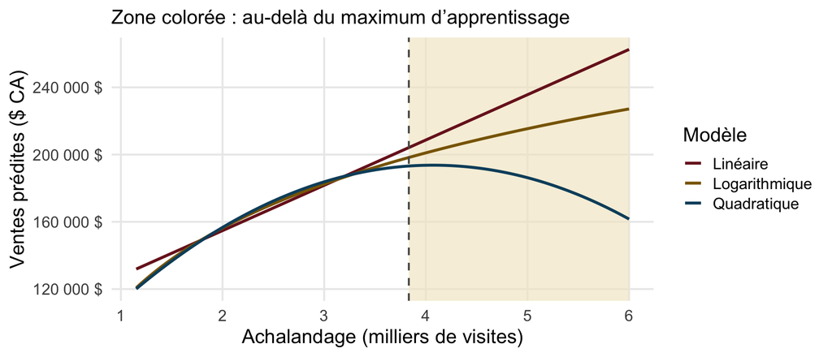

## À 6 000 visites

| Modèle | Ventes prédites (dollars) |
| --- | --- |
| Linéaire | 262 554 |
| Quadratique | 161 626 |
| Logarithmique | 227 144 |

Ces valeurs illustrent la fragilité de l’extrapolation. Elles ne sont pas des prévisions validées.

## Ce que le modèle ignore

- Répétitions mensuelles dans une même succursale.
- Saison, stock et marketing omis du modèle simple.
- Incertitude sur l’achalandage futur lui-même.

Les prédictions sont conditionnelles à l’achalandage fourni. Elles ne prévoient pas automatiquement l’achalandage du prochain mois.

## À retenir

Plage

rester près des données

Intervalle

rappeler ses hypothèses

Extrapolation

examiner la divergence

## Production autonome 4.5

Prédisez les ventes pour 2 500 visites avec le modèle quadratique et son intervalle de prédiction. Comparez ensuite les trois prédictions à 6 000 visites et expliquez pourquoi elles ne justifient pas une recommandation.

### Auto-vérification

- J’ai saisi 2,5 et 6 dans la variable en milliers.
- J’ai nommé les hypothèses de l’intervalle.
- Je situe les scénarios par rapport à la plage d’apprentissage.